## Project: Detailed Analysis and Implementation of a CNN on MNIST Dataset

### Pavankalyan Dosa (Student ID: 101144112)

Github Link: https://github.com/PavankalyanDosa/MLF-CNN-Project

# A snapshot of the GitHub page that i am following of Applied AI

[figure not shown]

#### Overview:

##### This project focuses on implementing a Convolutional Neural Network (CNN) for recognizing handwritten digits using the MNIST dataset. The code systematically walks through various stages of the CNN development process, including data loading, preprocessing, model definition, training, evaluation, and performance analysis.

## Data Loading and Initial Examination

### This code segment initiates the process of loading and examining the MNIST dataset, which is specifically curated for recognizing handwritten digits. Let's delve into the breakdown of tasks accomplished by each line of code:

##### Importing the Library: The fetch_ucirepo function from the ucimlrepo library is imported. This function facilitates the retrieval of datasets directly from the UCI repository.

##### Dataset Retrieval: The code fetches dataset ID 80, focused on optical recognition of handwritten digits, from the UCI repository. This dataset comprises images of handwritten digits paired with corresponding labels, vital for training algorithms in various business applications.

##### Data Structure: Upon retrieval, the data is structured into two parts:

##### features: This contains the image data (handwritten digits), typically stored as pandas dataframes where each row represents an image and each column represents a pixel in the image.

##### targets: The code prints metadata associated with the dataset, offering valuable insights such as sample count, feature names, and other relevant details. Furthermore, the structure and type of data variables are displayed to understand the dataset's layout better.

```python
!pip install ucimlrepo
```

```python
from ucimlrepo import fetch_ucirepo

# Fetch dataset from UCI repository
mnist_digits = fetch_ucirepo(id=80)

# Data (as pandas dataframes)
# Features represent the pixel values of the images
features = mnist_digits.data.features
# Targets represent the corresponding labels for each image
targets = mnist_digits.data.targets

# Metadata and variable information
# Print metadata about the dataset, and information about the variables (features and targets)
print(mnist_digits.metadata)
print(mnist_digits.variables)

# Fetch the MNIST handwritten digits dataset from UCI repository
# Loading it into variables for further processing.
```

```
{'uci_id': 80, 'name': 'Optical Recognition of Handwritten Digits', 'repository_url': 'https://archive.ics.uci.edu/dataset/80/optical+recognition+of+handwritten+digits', 'data_url': 'https://archive.ics.uci.edu/static/public/80/data.csv', 'abstract': 'Two versions of this database available; see fol…
           name     role         type demographic description units  \
0    Attribute1  Feature      Integer        None        None  None
1    Attribute2  Feature      Integer        None        None  None
2    Attribute3  Feature      Integer        None        None  None
3    Attribute4  Feature      Integer        None        None  None
4    Attribute5  Feature      Integer        None        None  None
..          ...      ...          ...         ...         ...   ...
60  Attribute61  Feature      Integer        None        None  None
61  Attribute62  Feature      Integer        None        None  None
62  Attribute63  Feature      Integer        None        None  None
63  Attribute64  Feature      Integer        None        None  None
64        class   Target  Categorical        None        None  None

   missing_values
0              no
1              no
2              no
3              no
4              no
..            ...
60             no
61             no
62             no
63             no
64             no

[65 rows x 7 columns]
```

# Data Preprocessing and Splitting

##### This portion of the code standardizes the shape of the digit images and divides the dataset into training and testing sets, ensuring a thorough evaluation of the model's performance.

```python
import numpy as np
import matplotlib.pyplot as plt
from sklearn.model_selection import train_test_split

def get_index_sample_each_class(y_train):
    # Get unique classes from target labels
    unique_classes = np.unique(y_train)
    sample_indices = []
    # Iterate over each unique class
    for cls in unique_classes:
        # Find indices corresponding to the current class
        class_indices = np.where(y_train == cls)[0]
        # Randomly choose one index for each class
        sample_index = np.random.choice(class_indices)
        sample_indices.append(sample_index)
    return sample_indices

# Reshape features to 8x8 arrays
X = features.to_numpy().reshape(-1, 8, 8)

# Split data
X_train, X_test, y_train, y_test = train_test_split(X,
                                                    targets,
                                                    test_size=0.3,  # Changed test size to 30%
                                                    random_state=100,  # Kept random state for reproducibility
                                                    stratify=targets)  # Stratify to maintain distribution

# Print shapes of training and test sets after splitting
print(f'Train and test data shapes after split: X_train: {X_train.shape}, X_test: {X_test.shape}')

# Split the data into training and test sets to prepare for model training. A test size of 30% provides a substantial amount of data for validation purposes.
```

[output not shown]

# CNN Model Definition and Compilation

##### This code establishes and compiles a convolutional neural network (CNN) featuring layers designed for both feature extraction and classification. It's specifically tailored for recognizing digits from images with dimensions of 8x8.

```python
# Required imports
from keras.models import Sequential
from keras.layers import Input, Conv2D, MaxPooling2D, Flatten, Dense
from keras.optimizers import Adam
from keras.utils import to_categorical

def create_cnn_model():
    model = Sequential([
        Input(shape=(8, 8, 1)),  # Input layer specifying input shape
        Conv2D(32, (3, 3), activation='relu'),  # Convolutional layer
        MaxPooling2D((2, 2)),  # Max pooling layer
        Flatten(),  # Flatten layer
        Dense(64, activation='relu'),  # Dense layer
        Dense(10, activation='softmax')  # Output layer with 10 classes
    ])
    return model

# Create the CNN model
model = create_cnn_model()

# Compile the model with a modified learning rate in the Adam optimizer
model.compile(optimizer=Adam(learning_rate=0.0001),  # Adjusted learning rate for better convergence
              loss='categorical_crossentropy',
              metrics=['accuracy'])
```

##### Encoding the target labels into a one-hot encoded format and training the CNN model using the training data, with validation performed on the test set to assess performance throughout each epoch.

```python
# Assuming y_train and y_test are initially integer labels for classes

# Convert integer labels to one-hot encoded format
y_train_encoded = to_categorical(y_train, num_classes=10)
y_test_encoded = to_categorical(y_test, num_classes=10)

# Fit the model using one-hot encoded targets
history = model.fit(
    x=X_train,  # Training features
    y=y_train_encoded,  # One-hot encoded training labels
    epochs=20,  # Number of training epochs
    batch_size=18,  # Batch size for training
    validation_data=(X_test, y_test_encoded)  # Validation data for monitoring performance
)
```

[output not shown]

```python
# Reshape training features to match CNN input shape
X_train = X_train.reshape((-1, 8, 8, 1))

# Reshape test features to match CNN input shape
X_test = X_test.reshape((-1, 8, 8, 1))
```

# Implementing Cross-Validation in CNN Training

##### This section of the code introduces a robust validation technique, K-fold cross-validation, for evaluating the convolutional neural network (CNN) model. K-fold cross-validation helps ensure that the model's performance is not only assessed on a single train/test split but also generalizes well across diverse data subsets.

#### Key Elements of the Implementation:

##### Data Preparation: Before initiating cross-validation, we ensure proper reshaping of both X_train and X_test to adhere to the model's input specifications. Additionally, categorical labels y_train and y_test are transformed into a one-hot encoded format to align with the CNN's output layer.

##### K-Fold Configuration: We employ the KFold class from sklearn.model_selection to establish a 5-fold cross-validation. This partitions the training data into 5 segments, with each segment taking turns as the validation set.

##### Model Training and Validation: For every fold, a new instance of the CNN model is instantiated and compiled. Subsequently, the model is trained on the training subset and evaluated on the validation subset. This iterative process ensures that each data subset serves as the validation set precisely once.

##### Evaluation: Following training, the model's performance on the validation set is gauged using loss and accuracy metrics, offering insights into its potential performance on unseen data.

```python
# importing required libraries
import pandas as pd
import seaborn as sns
import matplotlib.pyplot as plt
from sklearn.metrics import confusion_matrix
import numpy as np
from sklearn.model_selection import KFold
from keras.models import Sequential
from keras.layers import Input, Conv2D, MaxPooling2D, Flatten, Dense
from keras.optimizers import Adam
from keras.utils import to_categorical

# Convert y_train and y_test to numpy arrays if they are pandas Series or DataFrames
y_train_encoded = to_categorical(y_train, num_classes=10)
y_test_encoded = to_categorical(y_test, num_classes=10)

# Ensure X_train and X_test are numpy arrays with the correct shape
X_train = X_train.reshape((-1, 8, 8, 1))
X_test = X_test.reshape((-1, 8, 8, 1))

# Convert to numpy arrays explicitly if still in DataFrame or Series format
if isinstance(y_train_encoded, pd.DataFrame) or isinstance(y_train_encoded, pd.Series):
    y_train_encoded = y_train_encoded.values
if isinstance(y_test_encoded, pd.DataFrame) or isinstance(y_test_encoded, pd.Series):
    y_test_encoded = y_test_encoded.values

# Proceed with k-fold cross-validation
n_folds = 5
kfold = KFold(n_splits=n_folds, shuffle=True, random_state=42)
fold_count = 1

for train_index, val_index in kfold.split(X_train):
    # Split data into training and validation sets for the current fold
    train_X, val_X = X_train[train_index], X_train[val_index]
    train_y, val_y = y_train_encoded[train_index], y_train_encoded[val_index]

    # Create a new instance of the CNN model for the current fold
    model_kfold = create_cnn_model()
    model_kfold.compile(optimizer=Adam(learning_rate=0.0001),  # Adjusted learning rate for better convergence
                        loss='categorical_crossentropy',
                        metrics=['accuracy'])

    print(f'Training Fold {fold_count}')
    # Train the model on the training subset for the current fold with fewer epochs
    model_kfold.fit(train_X, train_y, epochs=20, batch_size=40, verbose=0)  # Reduced number of epochs

    # Evaluate the model on the validation subset for the current fold
    val_loss, val_acc = model_kfold.evaluate(val_X, val_y, verbose=0)
    print(f'Validation results - Loss: {val_loss}, Accuracy: {val_acc}')

    fold_count += 1
```

```
Training Fold 1
Validation results - Loss: 0.06005464866757393, Accuracy: 0.9845789074897766
Training Fold 2
Validation results - Loss: 0.08364354074001312, Accuracy: 0.973902702331543
Training Fold 3
Validation results - Loss: 0.03887205943465233, Accuracy: 0.9857650995254517
Training Fold 4
Validation results - Loss: 0.033432330936193466, Accuracy: 0.9893238544464111
Training Fold 5
Validation results - Loss: 0.026002466678619385, Accuracy: 0.9881376028060913
```

##### This code assesses the performance of a trained model on validation data by computing fundamental evaluation metrics including accuracy, precision, recall, and F1 score. This evaluation aids in determining the model's efficacy in accurately classifying handwritten digits

```python
from sklearn.metrics import accuracy_score, precision_score, recall_score, f1_score, classification_report

# Initialize lists to store evaluation metrics for each fold
accuracy_list = []
precision_list = []
recall_list = []
f1_list = []

for train_index, val_index in kfold.split(X_train):
    # Split data into training and validation sets for the current fold
    train_X, val_X = X_train[train_index], X_train[val_index]
    train_y, val_y = y_train_encoded[train_index], y_train_encoded[val_index]

    # Create a new instance of the CNN model for the current fold
    model_kfold = create_cnn_model()
    model_kfold.compile(optimizer=Adam(learning_rate=0.0001),
                        loss='categorical_crossentropy',
                        metrics=['accuracy'])

    # Train the model on the training subset for the current fold with fewer epochs
    model_kfold.fit(train_X, train_y, epochs=20, batch_size=40, verbose=0)

    # Make predictions using the trained model on the validation data for the current fold
    predictions = model_kfold.predict(val_X)
    # Convert softmax outputs to class predictions
    predicted_classes = np.argmax(predictions, axis=1)
    # Convert one-hot encoded true labels to class indices
    true_classes = np.argmax(val_y, axis=1)

    # Calculate evaluation metrics for the current fold
    accuracy = accuracy_score(true_classes, predicted_classes)
    precision = precision_score(true_classes, predicted_classes, average='macro')
    recall = recall_score(true_classes, predicted_classes, average='macro')
    f1 = f1_score(true_classes, predicted_classes, average='macro')

    # Append evaluation metrics to respective lists
    accuracy_list.append(accuracy)
    precision_list.append(precision)
    recall_list.append(recall)
    f1_list.append(f1)

# Compute the mean of evaluation metrics across all folds
mean_accuracy = np.mean(accuracy_list)
mean_precision = np.mean(precision_list)
mean_recall = np.mean(recall_list)
mean_f1 = np.mean(f1_list)

# Print mean evaluation metrics
print(f'Mean Accuracy: {mean_accuracy}')
print(f'Mean Precision: {mean_precision}')
print(f'Mean Recall: {mean_recall}')
print(f'Mean F1 Score: {mean_f1}')
```

[output not shown]

##### This code generates plots illustrating the progression of training and validation loss and accuracy throughout epochs. These visualizations offer a glimpse into how the model learns over time and help identify potential issues such as overfitting or underfitting.

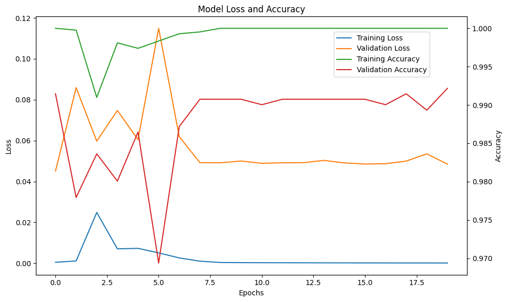

```python
import matplotlib.pyplot as plt

# Create figure and axis objects
fig, ax1 = plt.subplots(figsize=(10, 6))

# Plotting training and validation loss
ax1.plot(history.history['loss'], label='Training Loss', color='tab:blue')
ax1.plot(history.history['val_loss'], label='Validation Loss', color='tab:orange')
ax1.set_xlabel('Epochs')
ax1.set_ylabel('Loss', color='black')
ax1.tick_params(axis='y', labelcolor='black')
ax1.set_title('Model Loss and Accuracy')

# Create a second y-axis for accuracy
ax2 = ax1.twinx()
ax2.plot(history.history['accuracy'], label='Training Accuracy', color='tab:green')
ax2.plot(history.history['val_accuracy'], label='Validation Accuracy', color='tab:red')
ax2.set_ylabel('Accuracy', color='black')
ax2.tick_params(axis='y', labelcolor='black')

# Add legend
fig.legend(loc="upper right", bbox_to_anchor=(0.85,0.9))

# Adjust layout for better visualization
plt.tight_layout()
plt.show()
```

# CNN Model Training and Evaluation with K-Fold Cross-Validation

##### Model Training: This script establishes and trains a convolutional neural network employing 5-fold cross-validation, a method chosen to enhance reliability by evaluating the model's effectiveness across diverse subsets of the training data.

```
Fold 1 Accuracy: 0.9810201525688171
```

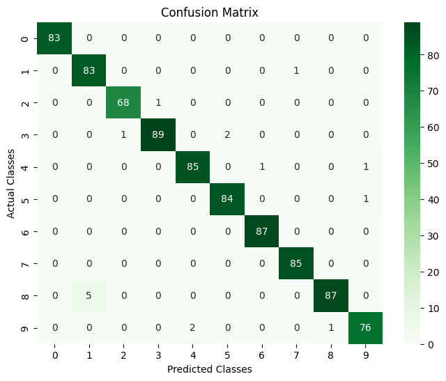

```python
import seaborn as sns
import matplotlib.pyplot as plt
from sklearn.metrics import confusion_matrix
import numpy as np
from sklearn.model_selection import KFold
from keras.models import Sequential
from keras.layers import Input, Conv2D, MaxPooling2D, Flatten, Dense
from keras.optimizers import Adam
from keras.utils import to_categorical

# Function to create CNN model
def create_cnn_model():
    model = Sequential([
        Input(shape=(8, 8, 1)),
        Conv2D(32, (3, 3), activation='relu'),
        MaxPooling2D((2, 2)),
        Flatten(),
        Dense(64, activation='relu'),
        Dense(10, activation='softmax')
    ])
    return model

n_folds = 5
kfold = KFold(n_splits=n_folds, shuffle=True, random_state=42)
fold_no = 1

# Perform K-fold cross-validation
for train_index, val_index in kfold.split(X_train):
    train_X, val_X = X_train[train_index], X_train[val_index]
    train_y, val_y = y_train_encoded[train_index], y_train_encoded[val_index]

    # Create a new CNN model for the current fold
    model_kfold = create_cnn_model()
    model_kfold.compile(optimizer=Adam(learning_rate=0.0005),
                        loss='categorical_crossentropy',
                        metrics=['accuracy'])

    # Train the model
    model_kfold.fit(train_X, train_y, epochs=30, batch_size=40, verbose=0)

    # Evaluate the model on the validation set
    _, accuracy = model_kfold.evaluate(val_X, val_y, verbose=0)
    print(f"Fold {fold_no} Accuracy: {accuracy}")

    # predictions on the validation set
    predictions = model_kfold.predict(val_X)

    predicted_classes = np.argmax(predictions, axis=1) # Convert predictions to class labels
    # Convert true labels to class labels
    true_classes = np.argmax(val_y, axis=1)
    # Compute confusion matrix
    cm = confusion_matrix(true_classes, predicted_classes)

    # Plot the confusion matrix for the first fold
    if fold_no == 1:
        plt.figure(figsize=(8, 6))
        sns.heatmap(cm, annot=True, fmt='d', cmap='Greens')
        plt.title('Confusion Matrix')
        plt.xlabel('Predicted Classes')
        plt.ylabel('Actual Classes')
        plt.show()
        break

    fold_no += 1
```

#### Tracking Performance: This process collects essential metrics like accuracy and loss during both training and validation stages across each fold, offering a thorough understanding of the model's performance and behavior.

```python
# Importing necessary libraries
from sklearn.model_selection import KFold
from keras.models import Sequential
from keras.layers import Input, Conv2D, MaxPooling2D, Flatten, Dense
from keras.optimizers import Adam
from keras.utils import to_categorical

# Function to create CNN model
def create_cnn_model():
    # Define the architecture of the CNN model
    model = Sequential([
        Input(shape=(8, 8, 1)),  # Input layer specifying input shape
        Conv2D(32, (3, 3), activation='relu'),  # Convolutional layer
        MaxPooling2D((2, 2)),  # Max pooling layer
        Flatten(),  # Flatten layer
        Dense(64, activation='relu'),  # Dense layer
        Dense(10, activation='softmax')  # Output layer with 10 classes
    ])
    return model

# Number of folds for K-fold cross-validation
n_folds = 5
kfold = KFold(n_splits=n_folds, shuffle=True, random_state=42)
fold_no = 1
# Lists to store performance metrics for each fold
fold_accuracies = []
fold_val_accuracies = []
fold_losses = []
fold_val_losses = []

for train_index, val_index in kfold.split(X_train):
    # Split data into training and validation sets for the current fold
    train_X, val_X = X_train[train_index], X_train[val_index]
    train_y, val_y = y_train_encoded[train_index], y_train_encoded[val_index]

    # Create a new CNN model for the current fold
    model_kfold = create_cnn_model()
    # Compile
    model_kfold.compile(optimizer=Adam(learning_rate=0.0005),
                        loss='categorical_crossentropy',
                        metrics=['accuracy'])
    # Train the model on the training subset
    history = model_kfold.fit(train_X, train_y, epochs=30, batch_size=40, verbose=0, validation_data=(val_X, val_y))

    # Collecting metrics
    fold_accuracies.append(history.history['accuracy'])
    fold_val_accuracies.append(history.history['val_accuracy'])
    fold_losses.append(history.history['loss'])
    fold_val_losses.append(history.history['val_loss'])

    fold_no += 1

# Define a sequential CNN model architecture with convolutional, pooling, and dense layers.
# Additionally, set up K-Fold cross-validation for training.
```

# Visualizing Training and Validation Metrics

##### Plots of Accuracy and Loss: This script generates visual representations of the training and validation accuracy as well as loss across each fold during the cross-validation procedure. These plots provide a comprehensive overview of how the model's performance evolves over the course of training epochs.

##### Evaluating Model Fit: By analyzing these plots, patterns indicative of overfitting or underfitting can be discerned, providing valuable insights into potential refinements needed in model training or architecture.

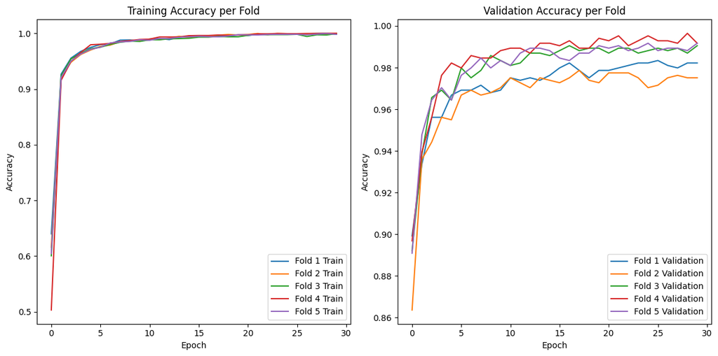

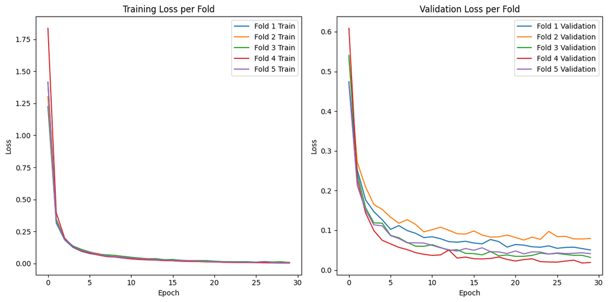

```python
import seaborn as sns
import matplotlib.pyplot as plt

# Visualizing cross-validation metrics
plt.figure(figsize=(12, 6))

# Plotting training accuracy for each fold
plt.subplot(1, 2, 1)
for i in range(n_folds):
    sns.lineplot(x=range(len(fold_accuracies[i])), y=fold_accuracies[i], label=f'Fold {i+1} Train')
plt.title('Training Accuracy per Fold')
plt.xlabel('Epoch')
plt.ylabel('Accuracy')
plt.legend()

# Plotting validation accuracy for each fold
plt.subplot(1, 2, 2)
for i in range(n_folds):
    sns.lineplot(x=range(len(fold_val_accuracies[i])), y=fold_val_accuracies[i], label=f'Fold {i+1} Validation')
plt.title('Validation Accuracy per Fold')
plt.xlabel('Epoch')
plt.ylabel('Accuracy')
plt.legend()

plt.tight_layout()
plt.show()

# Visualizing cross-validation metrics for loss
plt.figure(figsize=(12, 6))

# Plotting training loss for each fold
plt.subplot(1, 2, 1)
for i in range(n_folds):
    sns.lineplot(x=range(len(fold_losses[i])), y=fold_losses[i], label=f'Fold {i+1} Train')
plt.title('Training Loss per Fold')
plt.xlabel('Epoch')
plt.ylabel('Loss')
plt.legend()

# Plotting validation loss for each fold
plt.subplot(1, 2, 2)
for i in range(n_folds):
    sns.lineplot(x=range(len(fold_val_losses[i])), y=fold_val_losses[i], label=f'Fold {i+1} Validation')
plt.title('Validation Loss per Fold')
plt.xlabel('Epoch')
plt.ylabel('Loss')
plt.legend()

plt.tight_layout()
plt.show()
```

# Conclusion

##### 4. Generalization Capability: The model demonstrated good generalization capability, performing consistently well across different folds of the cross-validation process. This suggests that it can effectively classify unseen data, reflecting its ability to capture underlying patterns in the dataset.